# Question 1: How do the loan features of term, amount, and interest rate influence the likelihood of a loan being charged off versus being fully paid?

This question focuses on assessing risk levels and looking into trends of when the company can expect to see a loan charged off (lender has accepted the loan as unlikely to recover) or being paid off.

Assumptions: In terms of loan status, we are only analyzing the “Fully Paid” and “Charge Off” status.

## Data Types & Data Cleaning

For this question, we will be looking at the specific columns of funded amount, loan status, term, and interest rate. These attributes are defined as such:

1. Funded Amount: The total amount of the loan to be paid off.
2. Loan Status: Whether the loan has been fully paid or has been charged off. A loan that is fully paid is defined as a loan where the total payment has been met. A charge off status is defined as the lender accepting the loan as uncollectible. This differs from the default status in which payments are late but the lender expects to collect what the borrower still owes.
3. Term: How long the borrower has to pay off the loan (Either 36 or 60 Months).
4. Interest Rate: The percentage of the loan amount that the lender charges the borrower for borrowing money.

Based on this data, the funded amount and interest rate are data types that are numerical. On the other hand, loan status and term have been converted to factors and are categorical data types. While loan status logically makes sense to be categorical, term has been converted to a factor since there were only two types of loan terms (36 or 60 months) which can be seen as short term vs. long term when comparing the likelihood of default across loans. Term in this case will be viewed as nonlinear with interest rates and funded amount affecting risk with linearity.

To retrieve only this information, data cleaning was done on the accepted loans dataset that initially contained 2,157,894 million observations. After filtering to only see the four columns listed above in addition to filtering the loan status to either “Fully Paid” or “Charged Off”, the total observations stand at 1,245,285 observations.

```r
#Load Library
library(dplyr)

#Read the CSV
df <- read.csv("cleaned_accepted_2013_to_2018Q4.csv")

#Subset for Specific Columns
f_df<- df[, c("funded_amnt", "loan_status","term","int_rate")]

#Filter for specific loan status
df_filter <- f_df %>%
  filter(loan_status %in% c("Charged Off", "Fully Paid"))

#Convert loan status and term as factors
df_filter$loan_status <- as.factor(df_filter$loan_status)
df_filter$term <- as.factor(df_filter$term)


#Select Relevant Columns
df_final <-df_filter %>%
  select(funded_amnt, term, int_rate, loan_status)

#Check the Dataframe output
str(df_final)
```

```
## 'data.frame':    1245285 obs. of  4 variables:
##  $ funded_amnt: num  3600 24700 20000 10400 11950 ...
##  $ term       : Factor w/ 2 levels " 36 months"," 60 months": 1 1 2 2 1 1 1 1 1 1 ...
##  $ int_rate   : num  14 12 10.8 22.4 13.4 ...
##  $ loan_status: Factor w/ 2 levels "Charged Off",..: 2 2 2 2 2 2 2 2 2 2 ...
```

## Descriptive Statistics

Initial statistics summarizes data that can help in identifying patterns, trends, and outliers. To demonstrate this, loan status will be analyzed against each loan feature (term, amount and interest rate) to see any relationships and patterns.

### Relationship between Loan Status and Loan Term

```r
# Initialize Library
library(ggplot2)

# Contingency Table
c_table <- table(df_final$term, df_final$loan_status)
cat("Contingency Table: Loan Status by Term\n\n")
```

```
## Contingency Table: Loan Status by Term
```

```r
print(c_table)
```

```
##
##              Charged Off Fully Paid
##    36 months      153426     789214
##    60 months       99769     202876
```

```r
#Contingency Table by Proportions
prop_table <-prop.table(c_table) *100
cat("Contingency Table: Loan Status by Term Proportions (by %)\n\n")
```

```
## Contingency Table: Loan Status by Term Proportions (by %)
```

```r
print(prop_table)
```

```
##
##              Charged Off Fully Paid
##    36 months       12.32      63.38
##    60 months        8.01      16.29
```

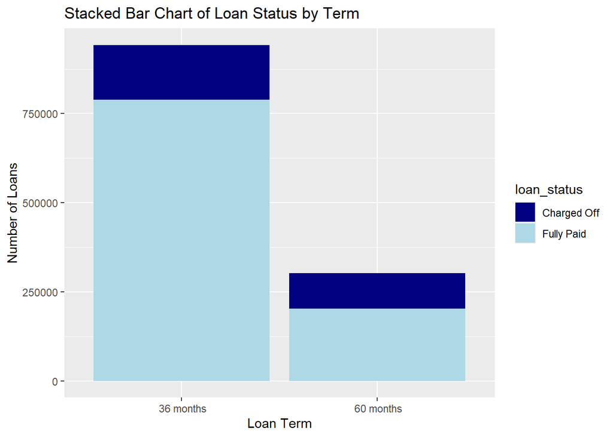

```r
# Stacked Bar Chart
ggplot(df_final, aes(x = term, fill = loan_status)) +
  geom_bar(position = "stack") +
  labs(x="Loan Term", y="Number of Loans",title="Stacked Bar Chart of Loan Status by Term" ) +
  scale_fill_manual(values = c("navy", "lightblue"))
```

## Relationship between Loan Status and Loan Amount

```r
# Descriptive Stats of Loan Amount Separated by Loan Status

amnt_stats <- df_final %>%
  group_by(loan_status) %>%
  summarise(
    Mean = mean(funded_amnt, na.rm = TRUE),
    Median = median(funded_amnt, na.rm = TRUE),
    SD = sd(funded_amnt, na.rm = TRUE),
    Q25 = quantile(funded_amnt, 0.25, na.rm = TRUE),
    Q50 = quantile(funded_amnt, 0.50, na.rm = TRUE),
    Q75 = quantile(funded_amnt, 0.75, na.rm = TRUE),
    Min = min(funded_amnt, na.rm = TRUE),
    Max = max(funded_amnt, na.rm = TRUE)
  )

cat("Descriptive Stats of Loan Amounts Separated by Loan Status)\n\n")
```

```
## Descriptive Stats of Loan Amounts Separated by Loan Status)
```

```r
print(amnt_stats)
```

```
## # A tibble: 2 × 9
##   loan_status   Mean Median    SD   Q25   Q50   Q75   Min   Max
##   <fct>        <dbl>  <dbl> <dbl> <dbl> <dbl> <dbl> <dbl> <dbl>
## 1 Charged Off 15666.  14400 8828.  9000 14400 20750  1000 40000
## 2 Fully Paid  14275.  12000 8722.  7500 12000 20000  1000 40000
```

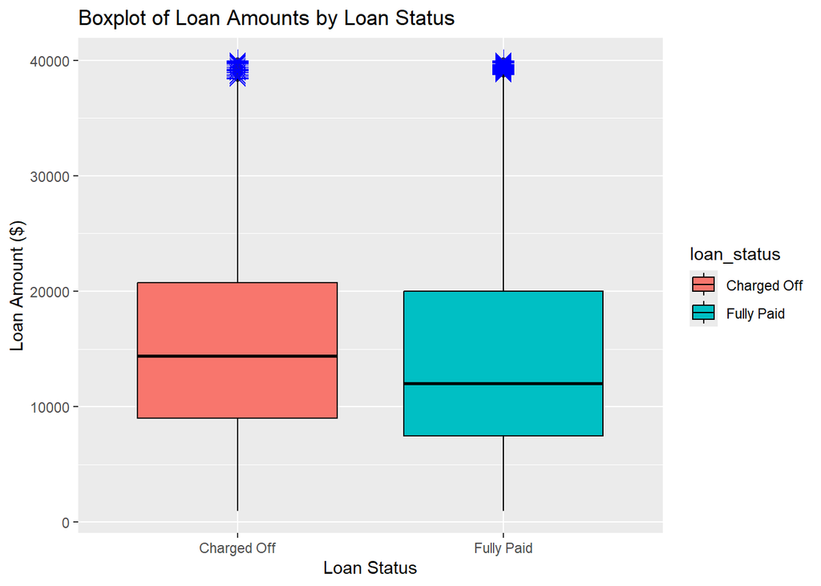

```r
# Box Plot Comparing Loan Amounts by Loan Status
ggplot(df_final, aes(x = loan_status, y=funded_amnt, fill = loan_status)) +
  geom_boxplot() +
  geom_boxplot( colour="black", outlier.colour="blue", outlier.shape=8, outlier.size=4) +
  labs(title="Boxplot of Loan Amounts by Loan Status", x="Loan Status", y = "Loan Amount ($)")
```

Based on the statistics, the following can be derived. With the charged off loans having a higher mean and median loan amount, this can suggest that the larger amounts may be associated with a higher risk of being charged off. Next, Charged off loans also have a slightly higher SD showing for more variability in the amounts.Lastly, both loan statuses show the same exact minimum and maximum but that does not necessarily mean that the distributions are identical.

Based on the boxplot, one commonality is the several outliers that exist around $40,000 for both loan statuses. However, this is not indicative that it is caused by status and requires further investigation through these high amounts being affected by other factors. Given the IQR of both statuses, there is not significant variability. You can however tell based on the IQR that the charged off loans have a slightly higher loan amounts compared to the fully paid loans that have a slightly lower loan amount.

Overall, larger loan amounts may be associated with a higher charged off risk.

## Relationship Between Loan Status and Interest Rate

```r
# Descriptive Stats of Interest Rate Separated by Loan Status

rate_stats <- df_final %>%
  group_by(loan_status) %>%
  summarise(
    Mean = mean(int_rate, na.rm = TRUE),
    Median = median(int_rate, na.rm = TRUE),
    SD = sd(int_rate, na.rm = TRUE),
    Q25 = quantile(int_rate, 0.25, na.rm = TRUE),
    Q50 = quantile(int_rate, 0.50, na.rm = TRUE),
    Q75 = quantile(int_rate, 0.75, na.rm = TRUE),
    Min = min(int_rate, na.rm = TRUE),
    Max = max(int_rate, na.rm = TRUE)
  )

cat("Descriptive Stats of Interest Rates Separated by Loan Status)\n\n")
```

```
## Descriptive Stats of Interest Rates Separated by Loan Status)
```

```r
print(rate_stats)
```

```
## # A tibble: 2 × 9
##   loan_status  Mean Median    SD   Q25   Q50   Q75   Min   Max
##   <fct>       <dbl>  <dbl> <dbl> <dbl> <dbl> <dbl> <dbl> <dbl>
## 1 Charged Off  15.8   15.0  4.95 12.3   15.0  18.6  5.31  31.0
## 2 Fully Paid   12.6   12.1  4.56  9.17  12.1  15.2  5.31  31.0
```

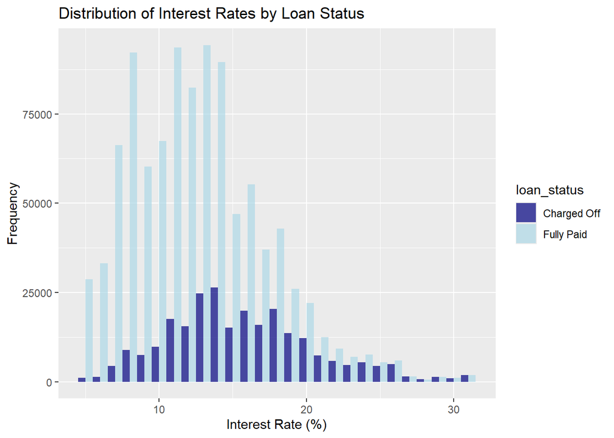

```r
library(ggplot2)
ggplot(df_final, aes(x = int_rate, fill = loan_status)) +
  geom_histogram(binwidth = 1, position = "dodge", alpha = 0.7)+
  labs(x="Interest Rate (%)", y="Frequency", title = "Distribution of Interest Rates by Loan Status") +
  scale_fill_manual(values = c("navy", "lightblue"))
```

Similar to the statistics, the histogram shows that interest rates have a strong influence on loan outcomes. Loans with a higher interest rate of around 15% and above are more likely to be charged off (in proportion to fully paid), indicating a greater risk of default at these levels. In contrast, lower interest rates between 10% to 12% are associated with a higher frequency of fully paid loans, suggesting that borrowers with lower rates are more likely to repay their loans in full. There is also a noticeable overlap in the 10% to 15% interest rate range, where fully paid and charged off loans occur. But as interest rates increase, the likelihood of a loan being charged off rises significantly. This suggests that interest rates are a key predictor of loan performance, with higher rates correlating strongly with loan defaults and lower rates with successful repayment.

## Multivariate Relationships